# Business Case

Session 1

Luis F. Gómez L.

luis.gomezl@unimilitar.edu.co

Distance Learning Faculty

14 September, 2026

# Please Read Me

- This presentation is based on a business case taken from the course [Data Science for Business Part 1](https://university.business-science.io/p/ds4b-101-r-business-analysis-r) offered by the company [Business Science](https://www.business-science.io/) and adapted to be in line with the topics covered in (Chapman & Feit, 2019)
- **Purpose**
  - Deliver essential knowledge within a minimal timeframe by employing hands-on learning techniques to enhance productivity in the R programming language

# Business Case

- You and your team will work for a corporation located in Wilton, Connecticut, United States that supplies bicycle frames and other components related to bicycles to different bicycle shops through the United States.
- Your team is assigned to complete 2 tasks:
  - Support the Research and Development (R & D) division in identifying potential new products and pricing them by using data collected from the bicycle shops.
  - Support the marketing team in the creation of a marketing segmentation clustering model by using data collected from to the bicycle shops to offer more personalized products and messaging them.
- Business unit: Cannondale Bicycle Corporation (Manufacturer)
  - Location: USA
  - Product: Bicycle frames
  - Retailers: Bikeshops located through USA
    - We are not going to analyze the business-to-customer (B2C) subchannel (Retailer to Customer) where the focus will be on the business-to-business (B2B) subchannel (Manufacturer to Retailer)

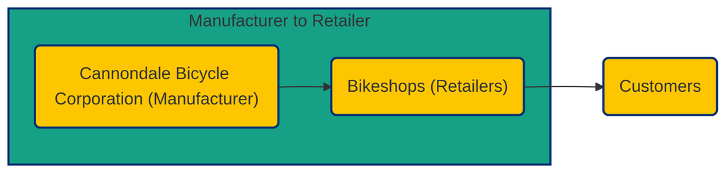

Figure 1: Distribution channel

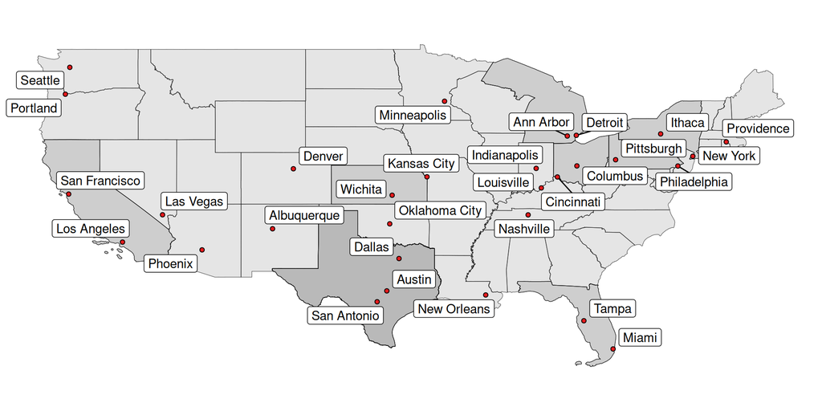

Figure 2: Bike shops locations

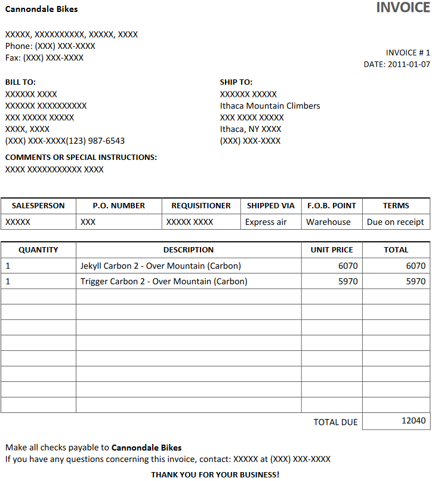

Figure 3: Invoice example representing a transaction

- Entities
  - **Product**
    - Product Id: unique product identification number
    - Model: model name of the bicycle
    - Category primary: main bicycle category (Mountain, Road)
    - Category secondary: More specific bicycle category (9 categories)
    - Frame: bicycle frame material (Carbon, Aluminum)
- Entities
  - **Retailer**
    - Bike shop Id: unique bike shop identification number
    - Bike shop name
    - Bike shop state: state that the bike shop is located
    - Bike shop city: city that the bike shop is located
    - Latitude: geograhpic latitude of the bike shop location
    - Longitude: geograhpic longitude of the bike shop location
- Entities
  - **Closed order**
    - Order Id: unique order identification number
    - Order date: date the order was placed
    - Order line: sequential identification number for products on an order
    - Quantity: number of units purchased by the retailer
    - Price: unit price of the bicycle
    - Bike shop Id: unique bike shop identification number
    - Product Id: unique product identification number

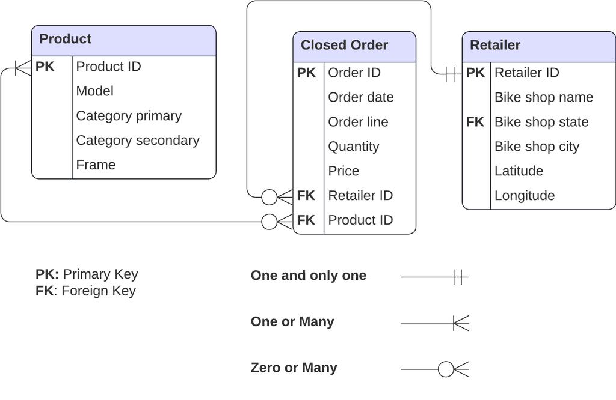

Figure 4: Database Entity Relationship Diagram (ERD)[^1]

```r
library(tidyverse) # Remember to load the tidyverse library
library(sweep) # Remember to load the sweep library
```

```r
bike_sales |> head(n = 8)
```

```
# A tibble: 8 × 17
  order.date order.id order.line quantity price price.ext customer.id
  <date>        <dbl>      <int>    <dbl> <dbl>     <dbl>       <dbl>
1 2011-01-07        1          1        1  6070      6070           2
2 2011-01-07        1          2        1  5970      5970           2
3 2011-01-10        2          1        1  2770      2770          10
4 2011-01-10        2          2        1  5970      5970          10
5 2011-01-10        3          1        1 10660     10660           6
6 2011-01-10        3          2        1  3200      3200           6
7 2011-01-10        3          3        1 12790     12790           6
8 2011-01-10        3          4        1  5330      5330           6
# ℹ 10 more variables: bikeshop.name <chr>, bikeshop.city <chr>,
#   bikeshop.state <chr>, latitude <dbl>, longitude <dbl>, product.id <dbl>,
#   model <chr>, category.primary <chr>, category.secondary <chr>, frame <chr>
```

```r
bike_sales |> View()
```

- Understand the business data
- Only works in Positron Pro
- Products
  - 97 bicycle models

Table 1: First 5 products

[output not shown]

- Retailers
  - 30 bike shops

Table 2: First 5 retailers

| Retailer Id | Bike shop name | City | State | Latitude | Longitude |
| --- | --- | --- | --- | --- | --- |
| 2 | Ithaca Mountain Climbers | Ithaca | NY | 42.44396 | -76.50188 |
| 10 | Kansas City 29ers | Kansas City | KS | 39.11405 | -94.62746 |
| 6 | Louisville Race Equipment | Louisville | KY | 38.25267 | -85.75846 |
| 22 | Ann Arbor Speed | Ann Arbor | MI | 42.28083 | -83.74304 |
| 8 | Denver Bike Shop | Denver | CO | 39.73924 | -104.99025 |

- Closed orders
  - 2000 orders

| Order date | Order Id | Order line | Quantity | Price | Retailer Id | Product Id |
| --- | --- | --- | --- | --- | --- | --- |
| 2011-01-07 | 1 | 1 | 1 | 6070 | 2 | 48 |
| 2011-01-07 | 1 | 2 | 1 | 5970 | 2 | 52 |
| 2011-01-10 | 2 | 1 | 1 | 2770 | 10 | 76 |
| 2011-01-10 | 2 | 2 | 1 | 5970 | 10 | 52 |
| 2011-01-10 | 3 | 1 | 1 | 10660 | 6 | 2 |
| 2011-01-10 | 3 | 2 | 1 | 3200 | 6 | 50 |
| 2011-01-10 | 3 | 3 | 1 | 12790 | 6 | 1 |
| 2011-01-10 | 3 | 4 | 1 | 5330 | 6 | 4 |
| 2011-01-10 | 3 | 5 | 1 | 1570 | 6 | 34 |
| 2011-01-11 | 4 | 1 | 1 | 4800 | 22 | 26 |
| 2011-01-11 | 5 | 1 | 1 | 480 | 8 | 96 |
| 2011-01-11 | 5 | 2 | 8 | 11190 | 8 | 66 |
| 2011-01-11 | 5 | 3 | 1 | 1250 | 8 | 35 |
| 2011-01-11 | 5 | 4 | 1 | 2060 | 8 | 72 |

# Acknowledgments

- To my family that supports me
- To the taxpayers of Colombia and the [**UMNG students**](https://www.umng.edu.co/estudiante) who pay my salary
- To the [**Business Science**](https://www.business-science.io/) and [**R4DS Online Learning**](https://www.rfordatasci.com/) communities where I learn [**R**](https://www.r-project.org/about.html) and [**$\pi$-thon**](https://www.python.org/about/)
- To the [**R Core Team**](https://www.r-project.org/contributors.html), the creators of [**Positron**](https://positron.posit.co/), [**Quarto**](https://quarto.org/) and the authors and maintainers of the packages [**tidyverse**](https://CRAN.R-project.org/package=tidyverse), [**tigris**](https://CRAN.R-project.org/package=tigris), [**janitor**](https://CRAN.R-project.org/package=janitor), [**ggrepel**](https://CRAN.R-project.org/package=ggrepel), [**sweep**](https://CRAN.R-project.org/package=sweep), [**gt**](https://CRAN.R-project.org/package=gt) and [**tinytex**](https://CRAN.R-project.org/package=tinytex) for allowing me to access these tools without paying for a license

# References

Abba, I. V. (2022). *Crow’s Foot Notation – Relationship Symbols And How to Read Diagrams*. https://www.freecodecamp.org/news/crows-foot-notation-relationship-symbols-and-how-to-read-diagrams/

Chapman, C., & Feit, E. M. (2019). *R For Marketing Research and Analytics* (2nd ed. 2019). Springer International Publishing : Imprint: Springer. https://doi-org.ezproxy.umng.edu.co/10.1007/978-3-030-14316-9

## Footnotes

[^1]: See (Abba, 2022)